# Relatório 3 – Análise estatística do banco de dados utilizado no Relatório 2, explorando as principais medidas de posição e de dispersão

Flávia Alves

15/09/2026

# 1 . Introdução

A Estatística é uma ferramenta importante para compreender melhor uma realidade a partir dos dados. No contexto educacional, ela pode ajudar a observar características dos estudantes, identificar padrões e compreender possíveis relações entre diferentes aspectos da vida escolar.

Neste relatório, será realizada uma análise estatística de um banco de dados com informações de 1.000 alunos. Os dados permitem observar aspectos relacionados ao desempenho escolar e às condições que fazem parte da realidade desses estudantes, como o número de faltas, a nota média, o turno de estudo, a escolaridade da mãe e o acesso à internet em casa.

A análise será desenvolvida utilizando o R e o RStudio, buscando apresentar os resultados de forma organizada, por meio de tabelas, medidas estatísticas e gráficos. Dessa maneira, pretende-se não apenas apresentar os números encontrados, mas também interpretá-los de forma simples e coerente com o contexto educacional.

# 2 . Objetivo

O presente relatório tem como objetivo aprofundar a análise estatística do banco de dados utilizado no Relatório 2, explorando as principais medidas de posição e de dispersão aplicadas às variáveis quantitativas do estudo.

A partir das variáveis Número de Faltas e Nota Média, os alunos deverão calcular, interpretar e comparar diferentes medidas estatísticas, buscando compreender não apenas o comportamento típico dos dados, mas também sua variabilidade. O objetivo deste relatório é analisar o banco de dados dos alunos e verificar o que os dados podem mostrar sobre o desempenho escolar e algumas características relacionadas à vida dos estudantes.

De forma mais específica, pretende-se observar a quantidade de faltas e as notas médias dos alunos, além de analisar possíveis relações entre o desempenho e fatores como o turno de estudo, o acesso à internet em casa e a escolaridade da mãe.

A intenção é utilizar a análise estatística para identificar padrões e diferenças presentes no banco de dados, sempre considerando que os resultados representam apenas os dados analisados e não devem ser utilizados, de forma automática, para representar todos os estudantes ou todas as escolas brasileiras.

# 3 . Descrição do banco de dados

O banco de dados utilizado neste relatório contém informações de 1.000 alunos e apresenta cinco variáveis. Essas variáveis foram escolhidas para representar diferentes aspectos relacionados à frequência, ao desempenho escolar e ao contexto sociofamiliar dos estudantes.

As variáveis analisadas são:

Faltas: representa a quantidade de ausências de cada aluno. No banco analisado, os valores variam de 1 a 19 faltas. Nota média: representa o desempenho acadêmico do aluno, com valores observados entre 0,5 e 10,0. Turno: indica o período em que o aluno estuda, podendo ser Matutino, Vespertino ou Noturno. Escolaridade da mãe: apresenta três categorias: Fundamental, Médio e Superior. Acesso à internet: informa se o aluno possui ou não acesso à internet em casa.

No conjunto de dados, 451 alunos estudam no turno matutino, 345 no vespertino e 204 no noturno. Em relação à escolaridade da mãe, 391 registros correspondem ao Ensino Fundamental, 459 ao Ensino Médio e 150 ao Ensino Superior. Quanto ao acesso à internet, 703 alunos possuem acesso em casa e 297 não possuem.

Em relação às variáveis numéricas, a média de faltas foi de aproximadamente 8,01 faltas, enquanto a média das notas foi de aproximadamente 6,44 pontos. Esses valores ajudam a apresentar uma visão inicial do comportamento dos dados antes da realização das análises mais detalhadas.

# 4 . Metodologia

A análise foi realizada utilizando o software R, por meio do ambiente RStudio. Inicialmente, o arquivo dados_alunos.csv foi importado para o R e os dados foram organizados para que cada variável pudesse ser analisada corretamente. Também foi realizada uma verificação inicial para confirmar a estrutura do banco e o tipo das informações utilizadas.

Em seguida, a análise foi organizada em três etapas principais.

Primeiramente, foi realizada uma análise univariada, na qual cada variável foi observada individualmente. Para as variáveis numéricas, foram calculadas medidas como média, mediana, mínimo e máximo. Também foram utilizados gráficos para facilitar a visualização da distribuição das faltas e das notas. Para as variáveis qualitativas, foram observadas as frequências de cada categoria.

Depois, foi realizada uma análise bivariada, buscando observar possíveis relações entre duas variáveis. Nessa etapa, foram analisadas, por exemplo, as relações entre acesso à internet e nota média, escolaridade da mãe e desempenho, número de faltas e nota média, além das diferenças entre os turnos de estudo.

Por fim, foi realizada uma análise multivariada, considerando mais de uma variável ao mesmo tempo. Um dos exemplos foi a análise conjunta do turno, do acesso à internet e da nota média, permitindo observar se determinados padrões aparecem quando essas características são consideradas simultaneamente.

Para apresentar os resultados de maneira mais clara, foram utilizados recursos gráficos e tabelas produzidos no R. Dessa forma, a metodologia busca combinar cálculos estatísticos com uma interpretação simples dos resultados, permitindo compreender melhor o comportamento dos dados analisados.

# 5 . Parte I: Medidas de posição

## 5.1 . Média aritmética

Nesta etapa, será calculada a média aritmética do número de faltas e da nota média dos alunos.

```r
# Importação do banco de dados

dados_alunos <- read.csv(
  "dados_alunos.csv",
  header = TRUE,
  sep = ";",
  dec = ",",
  stringsAsFactors = FALSE
)

# Transformação das variáveis numéricas

dados_alunos$faltas <- as.numeric(
  gsub(",", ".", dados_alunos$faltas)
)

dados_alunos$nota_media <- as.numeric(
  gsub(",", ".", dados_alunos$nota_media)
)
```

### 5.1.1 Média do número de faltas

```r
media_faltas <- mean(
  dados_alunos$faltas,
  na.rm = TRUE
)

round(media_faltas, 2)
```

```
## [1] 8.01
```

A média do número de faltas foi de **8,01 faltas**. Isso significa que os alunos analisados apresentaram, em média, aproximadamente 8 faltas.

### 5.1.2 Média da nota média

```r
media_nota <- mean(
  dados_alunos$nota_media,
  na.rm = TRUE
)

round(media_nota, 2)
```

```
## [1] 6.44
```

A média das notas dos alunos foi de **6,44 pontos**. Esse resultado indica que, considerando todos os alunos analisados, a nota média geral foi de aproximadamente 6,44 pontos.

## 5.2 Mediana

A mediana é o valor que ocupa a posição central dos dados quando eles estão organizados em ordem crescente.

### 5.2.1 Mediana do número de faltas

```r
mediana_faltas <- median(
  dados_alunos$faltas,
  na.rm = TRUE
)

round(mediana_faltas, 2)
```

```
## [1] 8
```

A mediana do número de faltas foi de **8 faltas**. Isso significa que metade dos alunos apresentou até 8 faltas e a outra metade apresentou 8 faltas ou mais.

### 5.2.2 Mediana da nota média

```r
mediana_nota <- median(
  dados_alunos$nota_media,
  na.rm = TRUE
)

round(mediana_nota, 2)
```

```
## [1] 6.5
```

A mediana da nota média foi de **6,50 pontos**. Isso indica que metade dos alunos apresentou nota média de até 6,50 pontos, enquanto a outra metade apresentou nota média igual ou superior a 6,50 pontos.

### 5.2.3 A média e a mediana apresentam valores próximos ou muito diferentes?

A média e a mediana apresentam **valores próximos** nas duas variáveis analisadas. Para as faltas, a média foi de **8,01** e a mediana foi de **8**. Para as notas, a média foi de **6,44** e a mediana foi de **6,50**.

Portanto, a diferença entre média e mediana é pequena, indicando que os valores estão relativamente próximos do centro da distribuição.

## 5.3 Moda

A moda é o valor que aparece com maior frequência em um conjunto de dados.

### 5.3.1 Moda do número de faltas

```r
moda_faltas <- as.numeric(
  names(sort(table(dados_alunos$faltas), decreasing = TRUE)[1])
)

moda_faltas
```

```
## [1] 7
```

### 5.3.2 Moda da nota média

```r
moda_nota <- as.numeric(
  names(sort(table(dados_alunos$nota_media), decreasing = TRUE)[1])
)

moda_nota
```

```
## [1] 10
```

## 5.4 Quartis

Os quartis dividem os dados organizados em quatro partes. Eles ajudam a entender como os valores estão distribuídos entre os alunos.

### 5.4.1 Quartis do número de faltas

```r
quartis_faltas <- quantile(
  dados_alunos$faltas,
  probs = c(0.25, 0.50, 0.75),
  na.rm = TRUE
)

round(quartis_faltas, 2)
```

```
## 25% 50% 75%
##   6   8  10
```

Os resultados mostram que:

- **1º quartil (Q1): 6 faltas** — 25% dos alunos apresentaram até 6 faltas.
- **2º quartil (Q2): 8 faltas** — corresponde à mediana; metade dos alunos apresentou até 8 faltas.
- **3º quartil (Q3): 10 faltas** — 75% dos alunos apresentaram até 10 faltas.

### 5.4.2 Quartis da nota média

```r
quartis_nota <- quantile(
  dados_alunos$nota_media,
  probs = c(0.25, 0.50, 0.75),
  na.rm = TRUE
)

round(quartis_nota, 2)
```

```
## 25% 50% 75%
## 5.2 6.5 7.7
```

Para as notas, os quartis mostram como o desempenho dos alunos está distribuído:

- **1º quartil (Q1): 5,20 pontos** — 25% dos alunos tiveram nota média de até 5,20.
- **2º quartil (Q2): 6,50 pontos** — corresponde à mediana; metade dos alunos teve nota de até 6,50.
- **3º quartil (Q3): 7,70 pontos** — 75% dos alunos tiveram nota média de até 7,70.

Assim, os quartis permitem observar de forma simples como as faltas e as notas estão distribuídas entre os estudantes analisados.

### 5.4.3 O que significa estar no primeiro quartil da distribuição das notas?

O primeiro quartil (Q1) das notas foi de **5,20 pontos**. Isso significa que aproximadamente **25% dos alunos apresentaram notas menores ou iguais a 5,20 pontos**, enquanto aproximadamente **75% dos alunos apresentaram notas iguais ou superiores a esse valor**.

Portanto, estar no primeiro quartil significa estar entre os **25% dos alunos com as menores notas** da distribuição.

## 5.5 Percentis

Os percentis ajudam a entender a posição de determinado valor dentro do conjunto de dados. Eles mostram, em porcentagem, até que ponto os valores estão distribuídos entre os alunos.

Neste relatório, serão observados os percentis 10, 25, 50, 75 e 90.

### 5.5.1 Percentis do número de faltas

```r
percentis_faltas <- quantile(
  dados_alunos$faltas,
  probs = c(0.10, 0.25, 0.50, 0.75, 0.90),
  na.rm = TRUE
)

round(percentis_faltas, 2)
```

```
## 10% 25% 50% 75% 90%
##   5   6   8  10  12
```

Os resultados permitem observar como o número de faltas está distribuído. Por exemplo, o percentil 50 corresponde à mediana, mostrando que metade dos alunos possui um número de faltas igual ou inferior a esse valor.

### 5.5.2 Percentis da nota média

```r
percentis_nota <- quantile(
  dados_alunos$nota_media,
  probs = c(0.10, 0.25, 0.50, 0.75, 0.90),
  na.rm = TRUE
)

round(percentis_nota, 2)
```

```
##  10%  25%  50%  75%  90%
## 3.99 5.20 6.50 7.70 9.10
```

No caso das notas, os percentis permitem identificar como o desempenho dos alunos está distribuído. Assim, é possível perceber a posição das notas mais baixas, intermediárias e mais altas dentro do conjunto analisado.

# 6 . Parte II: Medidas de dispersão

As medidas de dispersão ajudam a entender o quanto os valores dos alunos estão espalhados ou concentrados em torno dos valores centrais.

## 6.1 Amplitude total

A amplitude total mostra a diferença entre o maior e o menor valor encontrado. Quanto maior a amplitude, maior é a distância entre os extremos dos dados.

### 6.1.1 Amplitude das faltas

```r
amplitude_faltas <- max(dados_alunos$faltas, na.rm = TRUE) -
  min(dados_alunos$faltas, na.rm = TRUE)

amplitude_faltas
```

```
## [1] 18
```

A amplitude total do número de faltas foi de **18 faltas**, pois o menor número observado foi 1 e o maior foi 19.

### 6.1.2 Amplitude das notas

```r
amplitude_nota <- max(dados_alunos$nota_media, na.rm = TRUE) -
  min(dados_alunos$nota_media, na.rm = TRUE)

round(amplitude_nota, 2)
```

```
## [1] 9.5
```

A amplitude das notas foi de **9,50 pontos**, considerando a menor nota de 0,50 e a maior nota de 10,00.

## 6.2 Amplitude interquartil

A amplitude interquartil mostra a distância entre o primeiro e o terceiro quartil. Ela representa a variação dos 50% dos valores que estão no centro dos dados.

### 6.2.1 Amplitude interquartil das faltas

```r
aiq_faltas <- IQR(
  dados_alunos$faltas,
  na.rm = TRUE
)

round(aiq_faltas, 2)
```

```
## [1] 4
```

A amplitude interquartil das faltas foi de **4 faltas**. Isso mostra que os 50% dos alunos que estão na região central dos dados possuem uma diferença de aproximadamente 4 faltas entre o primeiro e o terceiro quartil.

### 6.2.2 Amplitude interquartil das notas

```r
aiq_nota <- IQR(
  dados_alunos$nota_media,
  na.rm = TRUE
)

round(aiq_nota, 2)
```

```
## [1] 2.5
```

A amplitude interquartil das notas foi de **2,50 pontos**. Isso significa que os 50% dos alunos que estão na parte central da distribuição apresentam notas dentro de uma faixa de 2,50 pontos.

## 6.3 Variância

A variância mostra o quanto os valores se afastam, em média, da média. Valores maiores indicam maior dispersão dos dados.

### 6.3.1 Variância das faltas

```r
variancia_faltas <- var(
  dados_alunos$faltas,
  na.rm = TRUE
)

round(variancia_faltas, 2)
```

```
## [1] 7.83
```

A variância do número de faltas foi de aproximadamente **7,84**. Esse resultado indica uma certa variação na quantidade de faltas entre os alunos.

### 6.3.2 Variância das notas

```r
variancia_nota <- var(
  dados_alunos$nota_media,
  na.rm = TRUE
)

round(variancia_nota, 2)
```

```
## [1] 3.54
```

A variância das notas foi de aproximadamente **3,55**, mostrando que as notas apresentam uma dispersão em relação à média.

## 6.4 Desvio-padrão

O desvio-padrão mostra, de maneira mais fácil de interpretar, o quanto os valores costumam se afastar da média.

### 6.4.1 Desvio-padrão das faltas

```r
desvio_faltas <- sd(
  dados_alunos$faltas,
  na.rm = TRUE
)

round(desvio_faltas, 2)
```

```
## [1] 2.8
```

O desvio-padrão das faltas foi de aproximadamente **2,80 faltas**. Isso significa que a quantidade de faltas dos alunos costuma variar cerca de 2,80 faltas em relação à média de 8,01 faltas.

### 6.4.2 Desvio-padrão das notas

```r
desvio_nota <- sd(
  dados_alunos$nota_media,
  na.rm = TRUE
)

round(desvio_nota, 2)
```

```
## [1] 1.88
```

O desvio-padrão das notas foi de aproximadamente **1,88 ponto**. Isso indica que as notas costumam se afastar cerca de 1,88 ponto da média geral de 6,44 pontos.

## 6.5 Coeficiente de variação

O coeficiente de variação permite comparar a dispersão de variáveis que possuem unidades diferentes. Ele é apresentado em porcentagem. Quanto maior o valor, maior é a variação dos dados em relação à própria média.

### 6.5.1 Coeficiente de variação das faltas

```r
cv_faltas <- (sd(dados_alunos$faltas, na.rm = TRUE) /
  mean(dados_alunos$faltas, na.rm = TRUE)) * 100

round(cv_faltas, 2)
```

```
## [1] 34.93
```

O coeficiente de variação das faltas foi de aproximadamente **34,92%**. Isso mostra que existe uma variação moderada na quantidade de faltas em relação à média.

### 6.5.2 Coeficiente de variação das notas

```r
cv_nota <- (sd(dados_alunos$nota_media, na.rm = TRUE) /
  mean(dados_alunos$nota_media, na.rm = TRUE)) * 100

round(cv_nota, 2)
```

```
## [1] 29.21
```

# 7 . Parte III: Análise por subgrupos

Nesta parte, os dados serão analisados considerando diferentes grupos de alunos. O objetivo é observar possíveis diferenças nas notas e nas faltas de acordo com o acesso à internet, a escolaridade da mãe e o turno em que o aluno estuda.

## 7.1 Notas segundo o acesso à internet

Nesta análise, vamos comparar as notas médias dos alunos que possuem acesso à internet com as notas dos alunos que não possuem acesso.

### 7.1.1 Alunos com acesso à internet

Os alunos que possuem acesso à internet apresentaram uma nota média de aproximadamente **6,43 pontos**.

### 7.1.2 Alunos sem acesso à internet

Os alunos que não possuem acesso à internet apresentaram uma nota média de aproximadamente **6,48 pontos**.

### 7.1.3 Comparando os resultados

Ao comparar os dois grupos, observa-se que os alunos sem acesso à internet apresentaram média de **6,48 pontos**, enquanto os alunos com acesso apresentaram média de **6,43 pontos**.

A diferença foi de aproximadamente **0,05 ponto**. Portanto, neste banco de dados, as médias dos dois grupos são muito próximas.

### 7.1.4 Os dois grupos apresentam comportamento semelhante em relação às notas?

Sim. De modo geral, os dois grupos apresentam **comportamento semelhante em relação às notas**. Os alunos com acesso à internet apresentaram média de **6,43 pontos**, enquanto os alunos sem acesso apresentaram média de **6,48 pontos**.

A diferença entre as médias foi de apenas **0,05 ponto**, indicando que os resultados dos dois grupos são muito próximos. Portanto, neste conjunto de dados, **não se observa uma diferença expressiva no desempenho das notas entre alunos com e sem acesso à internet**.

## 7.2 Notas segundo a escolaridade da mãe

Nesta análise, as notas serão comparadas de acordo com a escolaridade da mãe dos alunos.

### 7.2.1 Como o centro e a variabilidade das notas se comportam à medida que aumenta a escolaridade da mãe?

À medida que aumenta a escolaridade da mãe, observa-se uma **pequena tendência de aumento no centro das notas**. A média foi de aproximadamente **6,38 pontos** para Ensino Fundamental, **6,43 pontos** para Ensino Médio e **6,57 pontos** para Ensino Superior.

Assim, os alunos cujas mães possuem maior escolaridade apresentaram, em média, notas um pouco maiores. Entretanto, as diferenças entre os grupos são **pequenas**, não indicando uma diferença muito acentuada no desempenho.

### 7.2.2 Ensino Fundamental

Os alunos cujas mães possuem Ensino Fundamental apresentaram uma nota média de aproximadamente **6,38 pontos**.

### 7.2.3 Ensino Médio

Os alunos cujas mães possuem Ensino Médio apresentaram uma nota média de aproximadamente **6,43 pontos**.

### 7.2.4 Ensino Superior

Os alunos cujas mães possuem Ensino Superior apresentaram uma nota média de aproximadamente **6,57 pontos**.

### 7.2.5 Análise da escolaridade da mãe

Os resultados mostram pequenas diferenças entre as médias das notas de acordo com a escolaridade da mãe.

A maior média foi observada entre os alunos cujas mães possuem Ensino Superior, com aproximadamente **6,57 pontos**. Em seguida, aparecem os alunos cujas mães possuem Ensino Médio, com **6,43 pontos**, e os alunos cujas mães possuem Ensino Fundamental, com aproximadamente **6,38 pontos**.

Assim, neste conjunto de dados, observa-se uma tendência de aumento da média das notas conforme aumenta a escolaridade da mãe. Entretanto, as diferenças entre as médias são relativamente pequenas.

## 7.3 Faltas segundo o turno

Nesta análise, serão comparadas as médias de faltas dos alunos dos turnos Matutino, Vespertino e Noturno.

### 7.3.1 Matutino

Os alunos do turno Matutino apresentaram uma média de aproximadamente **8,03 faltas**.

### 7.3.2 Vespertino

Os alunos do turno Vespertino apresentaram uma média de aproximadamente **8,03 faltas**.

### 7.3.3 Noturno

Os alunos do turno Noturno apresentaram uma média de aproximadamente **7,95 faltas**.

### 7.3.4 Análise das faltas segundo o turno

Ao comparar os três turnos, observa-se que as médias de faltas são bastante próximas.

O turno Matutino apresentou aproximadamente **8,03 faltas**, o Vespertino também apresentou **8,03 faltas**, enquanto o Noturno apresentou aproximadamente **7,95 faltas**.

Dessa forma, os resultados indicam que não há uma diferença expressiva na média de faltas entre os três turnos. As pequenas diferenças encontradas fazem parte da variação observada nos dados.

### 7.3.5 Qual turno apresenta maior número típico de faltas?

Considerando a média de faltas, os turnos **Matutino e Vespertino** apresentaram o maior número típico de faltas, ambos com aproximadamente **8,03 faltas**. O turno Noturno apresentou uma média ligeiramente menor, de **7,95 faltas**.

Portanto, Matutino e Vespertino apresentam o maior número típico de faltas pela média.

### 7.3.7 A média e a mediana conduzem à mesma conclusão?

# 8 . Parte IV: Representação gráfica

## 8.1 Boxplot

O boxplot é uma representação gráfica que permite visualizar a distribuição dos dados, destacando a mediana, os quartis e a dispersão dos valores.

### 8.1.1 Boxplot das faltas

O boxplot das faltas permite observar a distribuição do número de faltas dos alunos. A linha central da caixa representa a mediana, enquanto os limites da caixa representam o primeiro e o terceiro quartis.

### 8.1.2 Boxplot das notas

O boxplot das notas permite visualizar a distribuição das notas médias dos alunos. A linha central representa a mediana e os limites da caixa representam os quartis.

## 8.2 Relação entre o boxplot e as medidas calculadas

O boxplot está diretamente relacionado às medidas de posição e dispersão calculadas anteriormente.

Para o número de faltas, a mediana foi de **8 faltas**, o primeiro quartil foi de **6 faltas** e o terceiro quartil foi de **10 faltas**. Dessa forma, a caixa do boxplot representa os 50% centrais dos alunos, que estão entre 6 e 10 faltas.

Para as notas médias, a mediana foi de **6,50 pontos**, o primeiro quartil foi de **5,20 pontos** e o terceiro quartil foi de **7,70 pontos**. Assim, a caixa representa os 50% centrais das notas, entre 5,20 e 7,70 pontos.

A distância entre o primeiro e o terceiro quartil corresponde à **amplitude interquartil**. Para as faltas, essa medida foi de **4 faltas**, enquanto para as notas foi de **2,50 pontos**.

Portanto, o boxplot permite visualizar graficamente algumas das principais medidas estatísticas calculadas anteriormente, facilitando a compreensão da distribuição, da posição central e da dispersão dos dados.

## 8.3 Relação entre o boxplot e as medidas calculadas

As informações apresentadas nos boxplots estão diretamente relacionadas às medidas de posição e de dispersão calculadas anteriormente. O boxplot permite visualizar, de forma resumida, a distribuição dos dados e facilita a interpretação dessas medidas.

No **boxplot das faltas**, a linha localizada no interior da caixa representa a **mediana**, que foi de **8 faltas**. A parte inferior da caixa corresponde ao **primeiro quartil (Q1)**, igual a **6 faltas**, enquanto a parte superior corresponde ao **terceiro quartil (Q3)**, igual a **10 faltas**. A distância entre Q1 e Q3 representa a **amplitude interquartil (AIQ)**, que foi de **4 faltas**.

No **boxplot das notas**, a mediana corresponde a **6,50 pontos**. O primeiro quartil foi de **5,20 pontos** e o terceiro quartil foi de **7,70 pontos**. Portanto, a amplitude interquartil das notas foi de **2,50 pontos**.

O boxplot também permite observar a **dispersão dos dados** e possíveis **valores extremos (outliers)**. Essas informações complementam medidas como o desvio-padrão, a variância e a amplitude total, calculadas anteriormente.

Assim, o boxplot apresenta visualmente informações que já foram obtidas por meio dos cálculos estatísticos. Ele permite identificar rapidamente a posição central dos dados, os 50% centrais da distribuição, a dispersão e possíveis valores extremos, tornando mais fácil compreender o comportamento das faltas e das notas dos alunos.

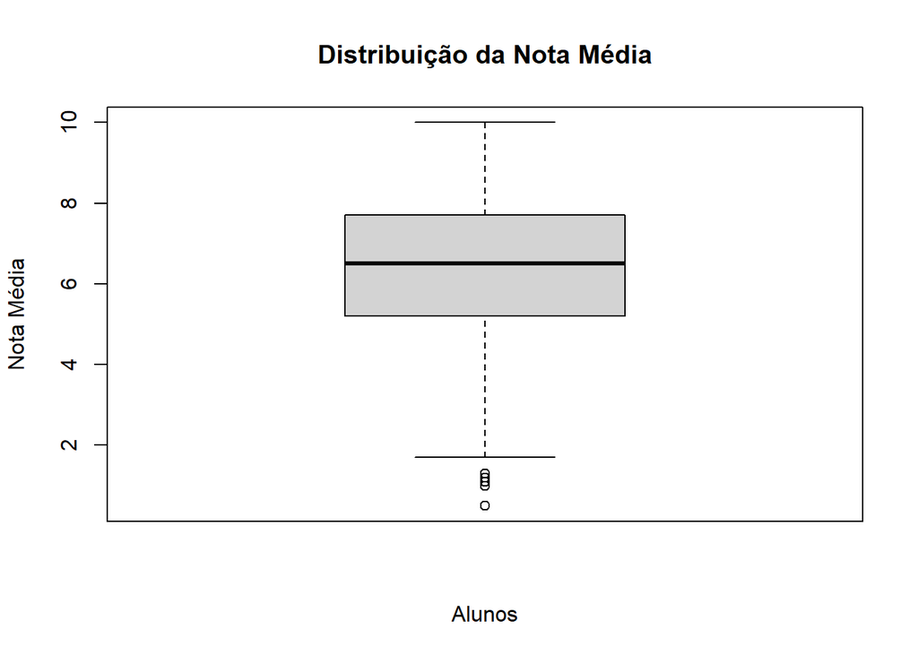

```r
# Representações gráficas

boxplot(dados_alunos$nota_media,
        main = "Distribuição da Nota Média",
        ylab = "Nota Média",
        xlab = "Alunos")
```

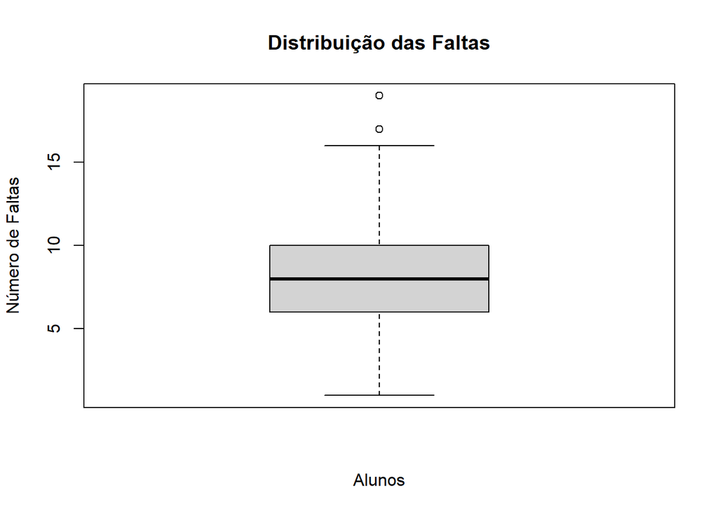

```r
boxplot(dados_alunos$faltas,
        main = "Distribuição das Faltas",
        ylab = "Número de Faltas",
        xlab = "Alunos")
```

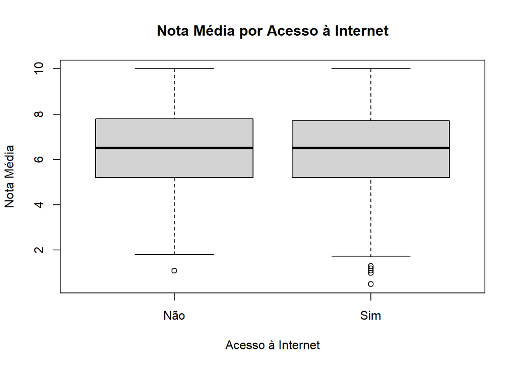

```r
boxplot(nota_media ~ acesso_internet,
        data = dados_alunos,
        main = "Nota Média por Acesso à Internet",
        xlab = "Acesso à Internet",
        ylab = "Nota Média")
```

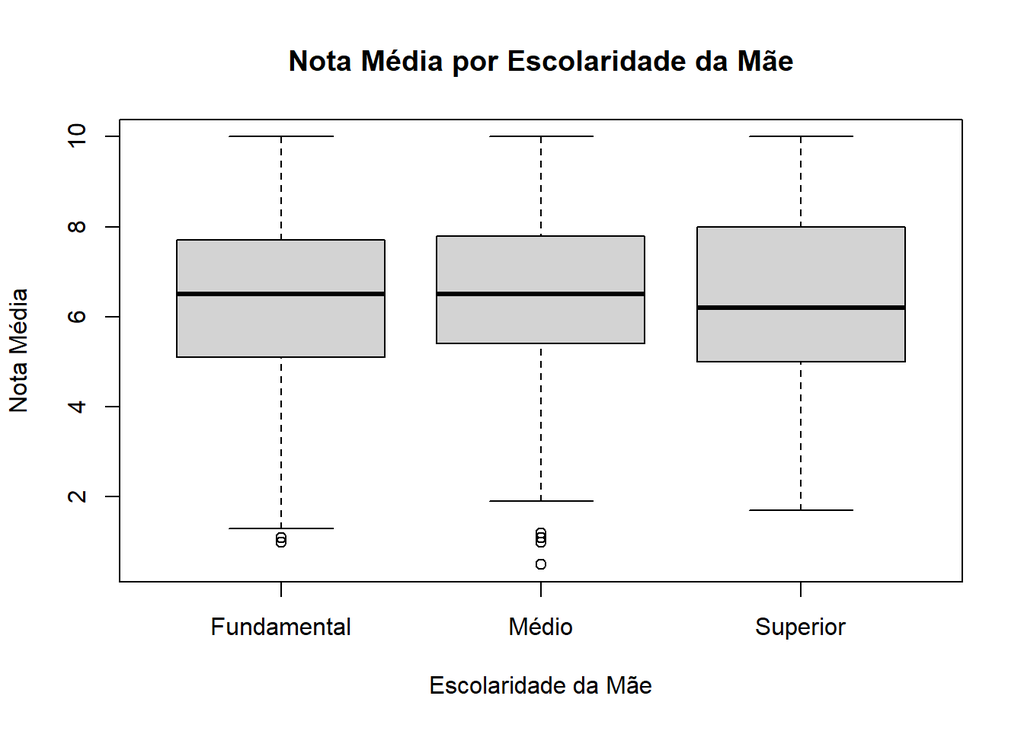

```r
boxplot(nota_media ~ escolaridade_mae,
        data = dados_alunos,
        main = "Nota Média por Escolaridade da Mãe",
        xlab = "Escolaridade da Mãe",
        ylab = "Nota Média")
```

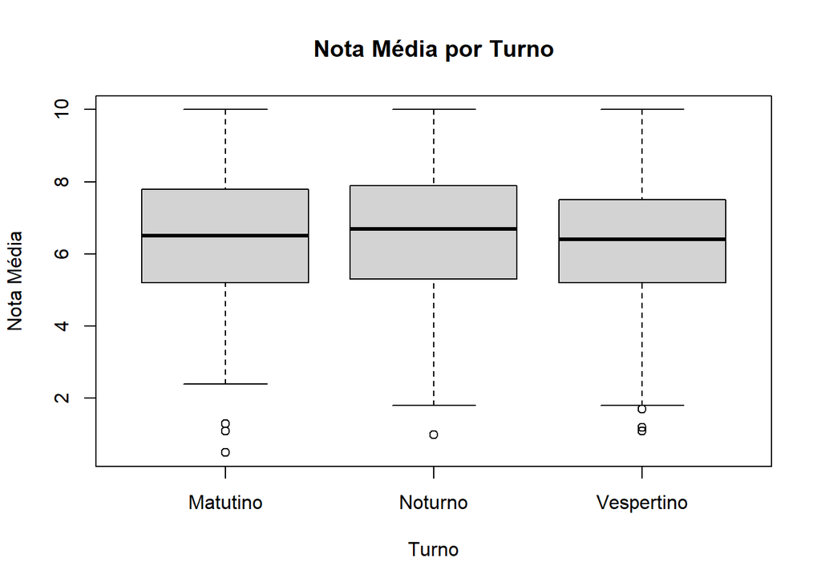

```r
boxplot(nota_media ~ turno,
        data = dados_alunos,
        main = "Nota Média por Turno",
        xlab = "Turno",
        ylab = "Nota Média")
```

## 8.4 Comparação entre grupos

A comparação entre grupos permite verificar como as notas dos alunos se distribuem de acordo com diferentes características. Para essa análise serão utilizados boxplots, pois eles permitem visualizar a mediana, os quartis, a dispersão e possíveis valores extremos das notas em cada grupo.

### 8.4.1 Distribuição das notas segundo o acesso à internet

Neste gráfico são comparadas as distribuições das notas dos alunos que possuem acesso à internet e dos alunos que não possuem acesso.

O boxplot permite comparar visualmente a distribuição das notas entre os dois grupos. É possível observar a posição da mediana, a amplitude dos 50% centrais dos dados e a dispersão das notas.

Os alunos com acesso à internet apresentaram média de aproximadamente **6,43 pontos**, enquanto os alunos sem acesso apresentaram média de aproximadamente **6,48 pontos**. As médias são bastante próximas, indicando pouca diferença no desempenho médio entre os dois grupos.

### 8.4.2 Distribuição das notas segundo a escolaridade da mãe

Neste gráfico são comparadas as distribuições das notas dos alunos segundo a escolaridade da mãe: Ensino Fundamental, Ensino Médio e Ensino Superior.

O gráfico permite comparar a distribuição das notas entre os três níveis de escolaridade da mãe. A posição das caixas e das medianas permite observar possíveis diferenças entre os grupos.

De maneira geral, os alunos cujas mães possuem Ensino Superior apresentaram a maior média de notas, seguidos pelos alunos cujas mães possuem Ensino Médio e Ensino Fundamental. As diferenças observadas entre os grupos são relativamente pequenas.

### 8.4.3 Distribuição das notas segundo o turno

Neste gráfico são comparadas as distribuições das notas dos alunos dos turnos Matutino, Vespertino e Noturno.

O boxplot permite visualizar e comparar a distribuição das notas nos três turnos. A posição das medianas e o tamanho das caixas ajudam a identificar diferenças na concentração e na dispersão das notas.

As médias das notas foram aproximadamente **6,46 pontos no Matutino**, **6,34 pontos no Vespertino** e **6,58 pontos no Noturno**. Apesar das diferenças, os valores são relativamente próximos entre os três turnos.

Dessa forma, os boxplots permitem visualizar de maneira mais clara as diferenças e semelhanças na distribuição das notas entre os grupos analisados.

# 9 . Parte IV: Representação gráfica

Os gráficos apresentados nesta parte têm como objetivo complementar as medidas estatísticas calculadas anteriormente. Por meio dos boxplots, é possível observar visualmente a posição central dos dados, a distribuição dos valores, a dispersão e a presença de possíveis valores extremos.

## 9.1 Boxplot das faltas

### 9.1.1 Interpretação estatística

O boxplot mostra a distribuição do número de faltas dos alunos.

A linha localizada dentro da caixa representa a **mediana**, que foi de **8 faltas**. A parte inferior da caixa corresponde ao primeiro quartil (Q1), igual a **6 faltas**, enquanto a parte superior corresponde ao terceiro quartil (Q3), igual a **10 faltas**.

Dessa forma, os **50% centrais dos alunos** apresentaram entre **6 e 10 faltas**. A distância entre esses dois valores corresponde à **amplitude interquartil (AIQ)**, que foi de **4 faltas**.

A amplitude total das faltas foi de **18 faltas**, considerando o menor valor observado de 1 e o maior de 19. O boxplot também permite observar possíveis valores extremos na distribuição.

De modo geral, o gráfico confirma os resultados obtidos anteriormente pelas medidas de posição e dispersão. A quantidade de faltas está concentrada principalmente em torno de **8 faltas**, embora exista uma variação entre os alunos.

## 9.2 Boxplot das notas

### 9.2.1 Interpretação estatística

O boxplot das notas mostra como o desempenho dos alunos está distribuído.

A linha central da caixa representa a **mediana**, que foi de **6,50 pontos**. O primeiro quartil (Q1) foi de **5,20 pontos** e o terceiro quartil (Q3) foi de **7,70 pontos**.

Isso significa que aproximadamente **50% das notas estão entre 5,20 e 7,70 pontos**. A amplitude interquartil foi de **2,50 pontos**, indicando a dispersão dos 50% centrais da distribuição.

A amplitude total foi de **9,50 pontos**, considerando a menor nota de **0,50** e a maior nota de **10,00**.

O gráfico permite perceber que as notas estão concentradas em torno da mediana de **6,50 pontos**, mas apresentam uma determinada dispersão entre os alunos. Essa informação complementa o desvio-padrão de aproximadamente **1,88 ponto** calculado anteriormente.

## 9.3 Comparação entre grupos

Os próximos boxplots permitem comparar a distribuição das notas entre diferentes grupos de alunos. Além das médias, serão observadas a posição central, a dispersão e a presença de possíveis valores extremos.

### 9.3.2 Interpretação estatística

O boxplot permite comparar visualmente as notas dos alunos com e sem acesso à internet.

As médias foram de aproximadamente **6,43 pontos** para os alunos com acesso à internet e **6,48 pontos** para os alunos sem acesso.

A diferença entre as médias foi de apenas **0,05 ponto**, indicando que os dois grupos apresentam resultados bastante próximos.

Portanto, a representação gráfica reforça a conclusão obtida na análise numérica: **não há uma diferença expressiva nas notas médias entre os alunos com e sem acesso à internet neste conjunto de dados**.

Além da média, o boxplot permite verificar se a mediana e a dispersão dos dois grupos também apresentam comportamentos semelhantes.

### 9.3.4 Interpretação estatística

O gráfico permite comparar a distribuição das notas de acordo com a escolaridade da mãe.

Os resultados anteriores mostraram médias aproximadas de **6,38 pontos** para Ensino Fundamental, **6,43 pontos** para Ensino Médio e **6,57 pontos** para Ensino Superior.

Observa-se, portanto, uma **pequena tendência de aumento das notas** conforme aumenta a escolaridade da mãe. Entretanto, as diferenças entre os grupos são relativamente pequenas.

O boxplot é importante porque permite verificar não apenas as médias, mas também as medianas, os quartis e a dispersão das notas dentro de cada grupo. Dessa maneira, é possível perceber se os alunos de cada grupo apresentam distribuições semelhantes ou diferentes.

### 9.3.6 Interpretação estatística

O boxplot permite comparar a distribuição das notas entre os três turnos.

As médias calculadas anteriormente foram de aproximadamente **6,46 pontos no Matutino**, **6,34 pontos no Vespertino** e **6,58 pontos no Noturno**.

O turno Noturno apresentou a maior média, enquanto o Vespertino apresentou a menor. Entretanto, as diferenças entre as médias são relativamente pequenas.

A análise do boxplot complementa essas informações, pois permite observar a mediana, os quartis e a dispersão das notas em cada turno. Assim, mesmo quando as médias são próximas, o gráfico pode mostrar diferenças na distribuição dos resultados.

De maneira geral, os boxplots indicam que as diferenças entre os grupos não são muito acentuadas. Portanto, é importante considerar não apenas a média, mas também a **mediana e a variabilidade** para realizar uma interpretação estatística mais completa.

## 9.4 Síntese da representação gráfica

Os boxplots complementam as medidas estatísticas calculadas anteriormente, permitindo visualizar informações que podem ser mais difíceis de perceber apenas por meio dos valores numéricos.

Para as **faltas**, observa-se concentração dos dados em torno de 8 faltas, com os 50% centrais situados entre 6 e 10 faltas.

Para as **notas**, a mediana foi de 6,50 pontos e os 50% centrais ficaram entre 5,20 e 7,70 pontos.

Nos gráficos por subgrupos, as diferenças entre os grupos são relativamente pequenas. Dessa forma, os boxplots confirmam a importância de analisar conjuntamente as medidas de **posição e dispersão**, evitando conclusões baseadas somente na média.

# 10 . Parte V: Análise Crítica

Nesta parte, os resultados obtidos nas etapas anteriores serão analisados de forma conjunta. O objetivo é compreender o que as medidas estatísticas revelam sobre o comportamento das faltas e das notas dos alunos.

## 10.1 9 Média versus mediana

A comparação entre média e mediana permite verificar se os valores estão distribuídos de forma equilibrada ou se existem diferenças provocadas por valores mais altos ou mais baixos.

Para o número de faltas, a média foi de aproximadamente **8,01 faltas**, enquanto a mediana foi de **8 faltas**. Como os dois valores são muito próximos, pode-se observar que a distribuição das faltas apresenta relativa proximidade em torno do valor central.

No caso das notas médias, a média foi de aproximadamente **6,44 pontos**, enquanto a mediana foi de **6,50 pontos**. Novamente, os valores são bastante próximos.

Essa pequena diferença entre média e mediana indica que não existe uma diferença muito acentuada entre essas duas medidas no conjunto de dados analisado. Portanto, tanto a média quanto a mediana são medidas adequadas para representar a posição central dos dados.

## 10.2 Média versus mediana

Para esta análise, foi escolhida a variável **nota_media**.

Se fosse necessário escolher apenas uma medida de posição para representar o comportamento típico dos alunos, eu escolheria a **mediana**.

A mediana das notas foi de **6,50 pontos**, enquanto a média aritmética foi de aproximadamente **6,44 pontos**. Embora os dois valores sejam bastante próximos, a mediana apresenta a vantagem de ser menos influenciada por valores muito baixos ou muito altos.

Nesse caso, a mediana de **6,50 pontos** indica que aproximadamente metade dos alunos apresentou nota igual ou inferior a esse valor e a outra metade apresentou nota igual ou superior.

Portanto, para representar o **comportamento típico dos alunos**, a mediana é uma medida adequada, pois representa a posição central da distribuição e é mais resistente à influência de valores extremos.

Assim, se fosse necessário escolher somente uma medida de posição, **a mediana seria a minha escolha para representar o comportamento típico das notas dos alunos**.

## 10.3 Efeito da variabilidade

A variabilidade mostra o quanto os valores dos alunos se afastam dos valores centrais.

Para as faltas, o desvio-padrão foi de aproximadamente **2,80 faltas** e a amplitude interquartil foi de **4 faltas**. Isso mostra que existe uma certa variação na quantidade de faltas entre os alunos.

Para as notas, o desvio-padrão foi de aproximadamente **1,88 ponto** e a amplitude interquartil foi de **2,50 pontos**. Portanto, embora existam diferenças entre as notas dos alunos, os valores apresentam uma concentração relativamente maior em torno da média.

Assim, proporcionalmente, o número de faltas apresentou maior variabilidade do que as notas. Isso significa que as faltas possuem uma dispersão relativamente maior em relação à sua própria média.

## 10.4 Medida mais adequada

A escolha da medida mais adequada depende do objetivo da análise e da forma como os dados estão distribuídos.

Neste conjunto de dados, a **média aritmética** é uma medida adequada para representar as notas e as faltas, pois a média e a mediana apresentaram valores bastante próximos. Isso indica que os valores centrais não apresentam uma diferença muito grande.

Entretanto, a **mediana** também é importante, principalmente porque é menos influenciada por valores extremos. Ela pode ser utilizada como uma medida complementar para representar o comportamento central dos dados.

Para uma análise mais completa, o ideal é utilizar a medida de posição juntamente com uma medida de dispersão. Dessa forma, não se observa apenas o valor central, mas também o quanto os dados variam.

Portanto, para este relatório, considera-se adequada a utilização da **média acompanhada do desvio-padrão**, complementada pela mediana e pela amplitude interquartil. Essa combinação permite uma interpretação mais completa do desempenho dos alunos e da quantidade de faltas.

## 10.5 Medidas estatísticas mais informativas em diferentes situações

Para cada situação, é possível escolher uma medida estatística que represente melhor a informação que se deseja obter.

### 10.5.1 a) Identificar o desempenho médio dos alunos

A medida mais informativa é a **média aritmética**.

A média permite resumir o desempenho de todos os alunos em um único valor, considerando todas as notas observadas. Neste conjunto de dados, a média das notas foi de aproximadamente **6,44 pontos**.

Portanto, quando o objetivo é identificar o desempenho médio geral da turma, a média aritmética é a medida mais adequada.

### 10.5.2 b) Identificar o desempenho típico quando existem valores extremos

A medida mais informativa é a **mediana**.

A mediana representa o valor central dos dados e é menos influenciada por valores muito baixos ou muito altos. Dessa forma, quando existem valores extremos, ela pode representar melhor o desempenho típico dos alunos.

Neste conjunto de dados, a mediana das notas foi de **6,50 pontos**.

### 10.5.3 c) Avaliar a dispersão das notas

A medida mais informativa é o **desvio-padrão**.

O desvio-padrão permite avaliar o quanto as notas costumam se afastar da média. Quanto maior o desvio-padrão, maior é a dispersão das notas.

Neste conjunto de dados, o desvio-padrão das notas foi de aproximadamente **1,88 ponto**, indicando o grau de variação das notas em torno da média de 6,44 pontos.

### 10.5.4 d) Comparar a variabilidade de duas variáveis com escalas diferentes

A medida mais informativa é o **coeficiente de variação (CV)**.

O coeficiente de variação expressa a dispersão em relação à própria média e é apresentado em porcentagem. Por isso, permite comparar a variabilidade relativa de variáveis que possuem unidades ou escalas diferentes.

### 10.5.5 e) Identificar a posição de um aluno em relação aos demais

A medida mais informativa é o **percentil**.

O percentil permite identificar a posição relativa de um aluno dentro do conjunto de dados. Por exemplo, estar no percentil 75 significa que o aluno apresenta um resultado igual ou superior ao de aproximadamente 75% dos valores observados.

Assim, os percentis são especialmente úteis para saber como o desempenho de um aluno se posiciona em relação aos demais alunos da turma.

### 10.5.6 Síntese

Dessa forma, as medidas mais informativas para cada situação são:

- **a) Desempenho médio:** média aritmética;
- **b) Desempenho típico com valores extremos:** mediana;
- **c) Dispersão das notas:** desvio-padrão;
- **d) Comparação da variabilidade em escalas diferentes:** coeficiente de variação;
- **e) Posição de um aluno em relação aos demais:** percentil.

A escolha da medida estatística deve considerar o objetivo da análise, pois cada medida fornece uma informação diferente sobre os dados.

# 11 . Parte VI: Tabela e gráficos estatísticos

Nesta parte do relatório, serão apresentados os principais resultados estatísticos obtidos nas análises anteriores por meio de uma tabela e de representações gráficas. A tabela permite visualizar de forma resumida as principais medidas calculadas, enquanto os gráficos facilitam a interpretação dos resultados.

## 11.1 Tabela estatística

A tabela abaixo apresenta as principais medidas de posição e dispersão das variáveis quantitativas analisadas: número de faltas e nota média.

```r
tabela_estatistica <- data.frame(
  Variável = c("Faltas", "Nota média"),
  Média = c(
    mean(dados_alunos$faltas, na.rm = TRUE),
    mean(dados_alunos$nota_media, na.rm = TRUE)
  ),
  Mediana = c(
    median(dados_alunos$faltas, na.rm = TRUE),
    median(dados_alunos$nota_media, na.rm = TRUE)
  ),
  Mínimo = c(
    min(dados_alunos$faltas, na.rm = TRUE),
    min(dados_alunos$nota_media, na.rm = TRUE)
  ),
  Máximo = c(
    max(dados_alunos$faltas, na.rm = TRUE),
    max(dados_alunos$nota_media, na.rm = TRUE)
  ),
  Desvio_Padrão = c(
    sd(dados_alunos$faltas, na.rm = TRUE),
    sd(dados_alunos$nota_media, na.rm = TRUE)
  ),
  CV = c(
    sd(dados_alunos$faltas, na.rm = TRUE) /
      mean(dados_alunos$faltas, na.rm = TRUE) * 100,
    sd(dados_alunos$nota_media, na.rm = TRUE) /
      mean(dados_alunos$nota_media, na.rm = TRUE) * 100
  )
)

tabela_estatistica$Média <- round(tabela_estatistica$Média, 2)
tabela_estatistica$Mediana <- round(tabela_estatistica$Mediana, 2)
tabela_estatistica$Mínimo <- round(tabela_estatistica$Mínimo, 2)
tabela_estatistica$Máximo <- round(tabela_estatistica$Máximo, 2)
tabela_estatistica$Desvio_Padrão <- round(
  tabela_estatistica$Desvio_Padrão, 2
)
tabela_estatistica$CV <- round(tabela_estatistica$CV, 2)

knitr::kable(
  tabela_estatistica,
  caption = "Principais medidas estatísticas"
)
```

Principais medidas estatísticas

| Variável | Média | Mediana | Mínimo | Máximo | Desvio_Padrão | CV |
| --- | --- | --- | --- | --- | --- | --- |
| Faltas | 8.01 | 8.0 | 1.0 | 19 | 2.80 | 34.93 |
| Nota média | 6.44 | 6.5 | 0.5 | 10 | 1.88 | 29.21 |

A tabela permite comparar rapidamente as duas variáveis. Observa-se que o número de faltas apresentou média de aproximadamente **8,01**, mediana de **8**, desvio-padrão de aproximadamente **2,80** e coeficiente de variação de **34,92%**.

## 11.2 Gráfico da distribuição das faltas

O gráfico abaixo apresenta a distribuição do número de faltas dos alunos.

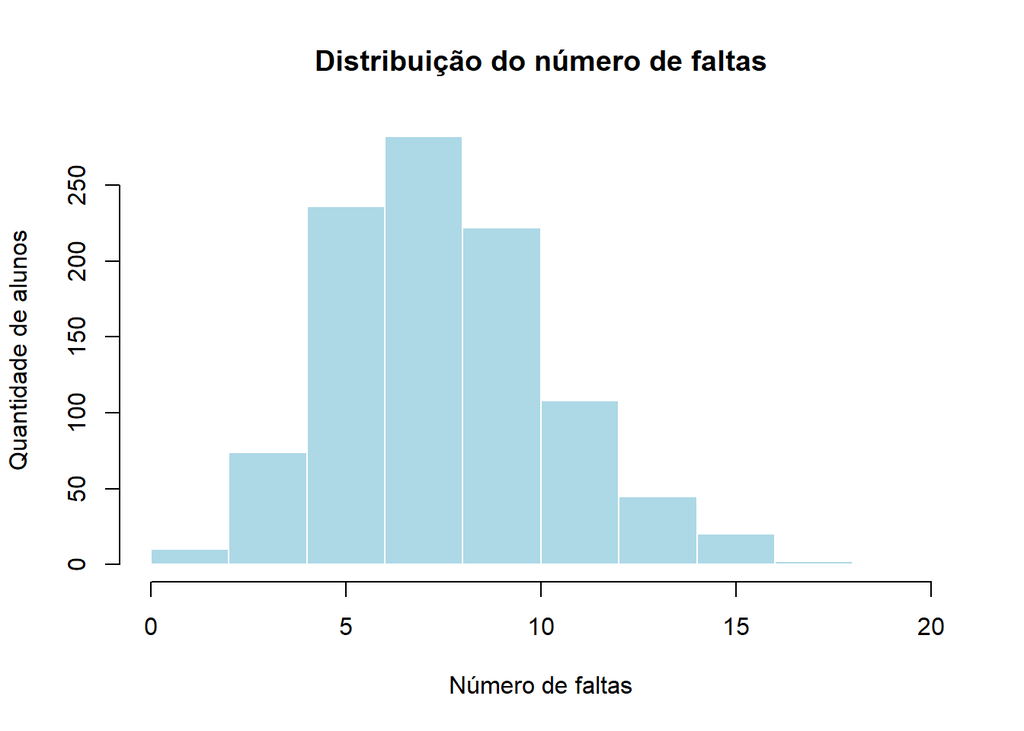

```r
hist(
  dados_alunos$faltas,
  main = "Distribuição do número de faltas",
  xlab = "Número de faltas",
  ylab = "Quantidade de alunos",
  col = "lightblue",
  border = "white"
)
```

O histograma permite observar a frequência dos diferentes números de faltas encontrados entre os alunos.

## 11.3 Gráfico da distribuição das notas

O gráfico abaixo apresenta a distribuição das notas médias dos alunos.

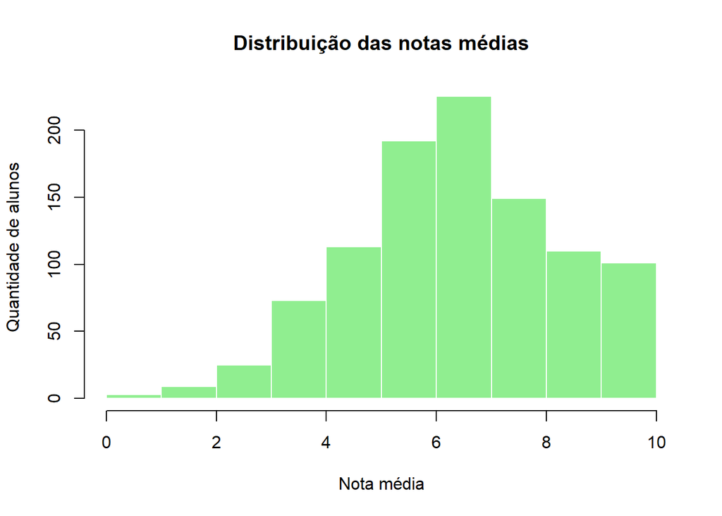

```r
hist(
  dados_alunos$nota_media,
  main = "Distribuição das notas médias",
  xlab = "Nota média",
  ylab = "Quantidade de alunos",
  col = "lightgreen",
  border = "white"
)
```

O histograma permite observar como as notas estão distribuídas, possibilitando identificar a concentração dos alunos em determinadas faixas de notas.

## 11.4 Gráfico das médias de notas por turno

Também é possível comparar as médias das notas de acordo com o turno dos alunos.

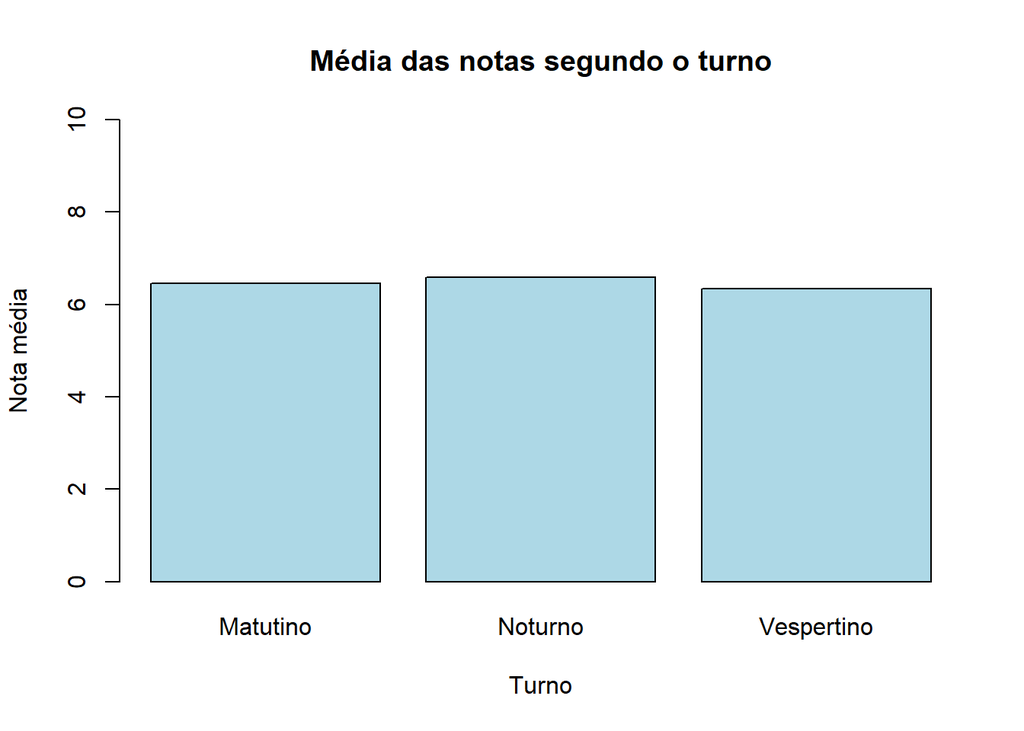

```r
medias_turno <- aggregate(
  nota_media ~ turno,
  data = dados_alunos,
  FUN = mean
)

barplot(
  medias_turno$nota_media,
  names.arg = medias_turno$turno,
  main = "Média das notas segundo o turno",
  xlab = "Turno",
  ylab = "Nota média",
  col = "lightblue",
  ylim = c(0, 10)
)
```

O gráfico permite observar que as médias das notas são relativamente próximas entre os três turnos. O turno Noturno apresentou a maior média, aproximadamente **6,58 pontos**, enquanto o Vespertino apresentou aproximadamente **6,34 pontos**.

## 11.5 Gráfico das médias de faltas por turno

Por fim, podemos comparar a média de faltas dos alunos segundo o turno.

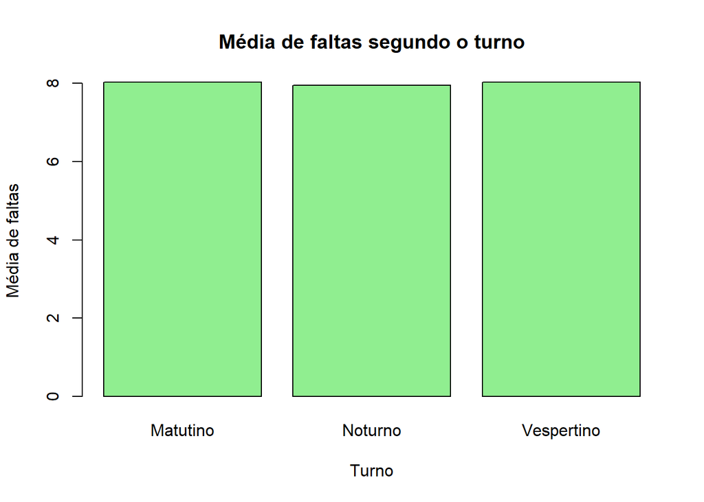

```r
medias_faltas_turno <- aggregate(
  faltas ~ turno,
  data = dados_alunos,
  FUN = mean
)

barplot(
  medias_faltas_turno$faltas,
  names.arg = medias_faltas_turno$turno,
  main = "Média de faltas segundo o turno",
  xlab = "Turno",
  ylab = "Média de faltas",
  col = "lightgreen"
)
```

As médias de faltas apresentaram valores bastante próximos entre os turnos. O Matutino e o Vespertino apresentaram aproximadamente **8,03 faltas**, enquanto o Noturno apresentou aproximadamente **7,95 faltas**.

## 11.6 Síntese dos resultados gráficos

Os gráficos apresentados ajudam a visualizar os resultados obtidos nas análises estatísticas. De maneira geral, observa-se que as notas dos alunos estão concentradas em torno de valores intermediários, enquanto o número de faltas apresenta uma distribuição mais espalhada.

A comparação entre os turnos também mostra que existem pequenas diferenças nas médias de notas e faltas, mas os valores permanecem relativamente próximos.

Dessa forma, a utilização conjunta de **tabelas e gráficos** facilita a compreensão dos resultados e permite apresentar as informações estatísticas de maneira mais clara e objetiva.

# 12 Síntese e reflexão: Discussão dos resultados

Nesta parte final do relatório, os principais resultados obtidos são retomados e interpretados de forma conjunta. O objetivo é compreender o comportamento das notas médias e do número de faltas, além de analisar as diferenças observadas entre os grupos.

É importante destacar que os resultados apresentados neste relatório representam uma **descrição estatística dos dados analisados**. A existência de diferenças entre grupos não significa, por si só, que uma variável seja responsável pela outra.

## 12.1 Qual medida de posição melhor representa o comportamento das notas médias dos alunos?

Para as notas médias, a **média aritmética** é uma medida adequada para representar o comportamento central dos dados. A média das notas foi de aproximadamente **6,44 pontos**, enquanto a mediana foi de **6,50 pontos**.

Como os dois valores são muito próximos, observa-se que não existe uma diferença acentuada entre essas medidas. Isso indica que a média consegue representar de maneira razoável o comportamento central das notas.

A mediana também é importante, pois apresenta menor influência de valores extremos. Portanto, para as notas, a média pode ser utilizada como medida principal, acompanhada da mediana para complementar a interpretação.

## 12.2 Qual medida de posição melhor representa o comportamento do número de faltas?

Para o número de faltas, a **média aritmética** também representa adequadamente o comportamento central dos dados.

A média foi de aproximadamente **8,01 faltas**, enquanto a mediana foi de **8 faltas**. A proximidade entre esses valores indica que a média não está muito distante do valor central observado.

Assim, a média pode ser utilizada para representar o número de faltas, enquanto a mediana serve como uma medida complementar, especialmente em uma situação em que se deseja reduzir a influência de possíveis valores extremos.

## 12.3 Qual das duas variáveis apresenta maior variabilidade relativa?

A variável que apresentou **maior variabilidade relativa foi o número de faltas**.

Como o coeficiente de variação permite comparar a dispersão relativa de variáveis diferentes, esses resultados indicam que o número de faltas apresenta maior variabilidade em relação à sua própria média.

## 12.4 A análise das medidas de dispersão modificou alguma conclusão que poderia ser obtida apenas pela média?

Sim. A análise das medidas de dispersão complementou a interpretação que seria obtida apenas observando as médias.

Ao analisar somente as médias, podemos identificar os valores centrais, como a média de **8,01 faltas** e a média de **6,44 pontos** nas notas. Entretanto, a média não mostra o quanto os valores variam entre os alunos.

Quando são considerados o desvio-padrão, a amplitude interquartil e o coeficiente de variação, percebe-se que existe uma variação considerável nos dados.

O coeficiente de variação mostrou, por exemplo, que as faltas possuem maior variabilidade relativa do que as notas. Portanto, as medidas de dispersão tornam a análise mais completa e evitam uma interpretação baseada somente nos valores médios.

## 12.5 Quais diferenças foram observadas entre os grupos analisados?

Foram observadas algumas diferenças entre os grupos analisados.

Em relação ao **acesso à internet**, os alunos com acesso apresentaram média de aproximadamente **6,43 pontos**, enquanto os alunos sem acesso apresentaram média de aproximadamente **6,48 pontos**. A diferença foi pequena, de aproximadamente **0,05 ponto**.

Considerando a **escolaridade da mãe**, os alunos cujas mães possuem Ensino Fundamental apresentaram média aproximada de **6,38 pontos**, os alunos cujas mães possuem Ensino Médio apresentaram aproximadamente **6,43 pontos** e aqueles cujas mães possuem Ensino Superior apresentaram aproximadamente **6,57 pontos**.

Em relação ao **turno**, as médias de faltas também foram bastante próximas: aproximadamente **8,03 faltas no Matutino**, **8,03 no Vespertino** e **7,95 no Noturno**.

Nas notas, foram observadas médias aproximadas de **6,46 pontos no Matutino**, **6,34 no Vespertino** e **6,58 no Noturno**.

Portanto, existem diferenças entre os grupos, mas, em geral, elas não são muito grandes.

## 12.6 Quais cuidados devem ser tomados ao interpretar essas diferenças?

É necessário ter cuidado para não interpretar automaticamente uma diferença entre médias como uma diferença significativa ou como uma relação de causa e efeito.

Uma diferença observada nos dados pode ocorrer devido à própria variabilidade da amostra. Além disso, os grupos podem possuir quantidades diferentes de alunos, o que também deve ser considerado na interpretação.

Outro cuidado importante é observar não apenas as médias, mas também a mediana, os quartis, o desvio-padrão e outras medidas de dispersão. Duas populações podem apresentar médias semelhantes e, ao mesmo tempo, distribuições bastante diferentes.

Assim, os resultados deste relatório devem ser interpretados como **diferenças descritivas observadas nos dados**, e não como provas de que uma característica determina o desempenho dos alunos.

## 12.7 Quais limitações devem ser consideradas antes de afirmar que as variáveis sociofamiliares são responsáveis pelo desempenho dos alunos?

Uma das principais limitações é que os dados analisados permitem identificar **associações ou diferenças entre grupos**, mas não permitem afirmar, sozinhos, que uma variável seja a causa do desempenho escolar.

Por exemplo, o fato de os alunos cujas mães possuem maior escolaridade apresentarem uma média de notas um pouco maior não significa que a escolaridade da mãe seja, isoladamente, responsável por essa diferença.

Existem diversos outros fatores que podem influenciar o desempenho escolar, como condições econômicas, apoio familiar, qualidade da escola, frequência, hábitos de estudo, acesso a materiais educacionais, características individuais dos alunos e outros fatores que não foram analisados neste relatório.

Também é importante considerar que uma associação estatística não comprova causalidade. Para afirmar que uma variável causa determinada mudança no desempenho, seriam necessárias análises mais aprofundadas, com controle de outras variáveis e, dependendo da questão de pesquisa, métodos estatísticos apropriados para investigar relações causais.

Dessa forma, os resultados deste relatório devem ser apresentados com cautela. O que os dados permitem afirmar é que **foram observadas diferenças entre determinados grupos**, mas não que essas diferenças foram necessariamente causadas pelas características sociofamiliares.

## 12.8 Conclusão da análise

De maneira geral, a análise mostrou que as notas médias apresentaram média de aproximadamente **6,44 pontos** e mediana de **6,50 pontos**, enquanto o número de faltas apresentou média de **8,01** e mediana de **8 faltas**.

Também foram identificadas diferenças entre grupos segundo acesso à internet, escolaridade da mãe e turno. Essas diferenças, entretanto, devem ser interpretadas como **resultados descritivos**.

Portanto, a principal conclusão é que a estatística permite organizar, resumir e comparar os dados, mas é necessário cuidado para não transformar uma diferença observada em uma afirmação de causalidade. Os resultados apresentados ajudam a compreender o conjunto de alunos analisado, mas não são suficientes, isoladamente, para afirmar que determinada característica sociofamiliar seja responsável pelo desempenho escolar.

# 13 Conclusões

A análise dos dados mostrou que as notas médias dos alunos foram de aproximadamente **6,44 pontos**, enquanto o número médio de faltas foi de **8,01**. As médias e medianas apresentaram valores próximos, indicando uma representação adequada do comportamento central dos dados.

O número de faltas apresentou maior variabilidade relativa que as notas. As diferenças observadas entre os grupos foram pequenas e devem ser interpretadas com cautela, pois os dados permitem identificar diferenças e associações, mas não permitem afirmar relações de causa e efeito.

Assim, o estudo possibilitou compreender, de forma objetiva, o comportamento das notas, das faltas e das características dos grupos analisados.

# 14 Limitações da análise

A análise foi realizada com base nos dados disponíveis no banco de dados, considerando principalmente estatísticas descritivas. Portanto, os resultados representam apenas o grupo de alunos analisado.

As diferenças encontradas entre os grupos não permitem afirmar relações de causa e efeito. Outros fatores que podem influenciar as notas e as faltas não foram analisados. Além disso, não foram realizados testes estatísticos de significância.

Dessa forma, os resultados devem ser interpretados como uma descrição dos dados, evitando conclusões de causalidade sobre as características dos alunos e seu desempenho escolar.

# 15 Código R utilizado

Nesta seção são apresentados os códigos em R utilizados para a importação, organização, análise estatística e representação gráfica dos dados apresentados ao longo deste relatório.

# 16 Lista de códigos

A seguir são apresentados alguns dos principais códigos em R utilizados na realização das análises estatísticas deste relatório.

## 16.1 Importação dos dados

```r
dados_alunos <- read.csv2(
  "dados_alunos.csv",
  header = TRUE,
  dec = ",",
  stringsAsFactors = FALSE
)
```

## 16.2 Cálculo da média

```r
mean(dados_alunos$nota_media, na.rm = TRUE)
```

## 16.3 Cálculo da mediana

```r
median(dados_alunos$nota_media, na.rm = TRUE)
```

## 16.4 Cálculo dos quartis

```r
quantile(
  dados_alunos$nota_media,
  probs = c(0.25, 0.50, 0.75),
  na.rm = TRUE
)
```

## 16.5 Cálculo do desvio-padrão

```r
sd(dados_alunos$nota_media, na.rm = TRUE)
```

## 16.6 Cálculo da variância

```r
var(dados_alunos$nota_media, na.rm = TRUE)
```

## 16.7 Cálculo do coeficiente de variação

```r
(
  sd(dados_alunos$nota_media, na.rm = TRUE) /
  mean(dados_alunos$nota_media, na.rm = TRUE)
) * 100
```

## 16.8 Comparação das médias por grupo

```r
aggregate(
  nota_media ~ turno,
  data = dados_alunos,
  FUN = mean
)
```

## 16.9 Boxplot

```r
boxplot(
  dados_alunos$nota_media ~ dados_alunos$turno,
  main = "Distribuição das notas segundo o turno",
  xlab = "Turno",
  ylab = "Nota média"
)
```

## 16.10 Histograma

```r
hist(
  dados_alunos$nota_media,
  main = "Distribuição das notas médias",
  xlab = "Nota média",
  ylab = "Quantidade de alunos"
)
```

Esses comandos representam as principais etapas utilizadas para **importar, calcular, comparar e representar graficamente os dados** analisados no relatório.

# 17 Referências bibliográficas

BENÊVIDE, B. **Probabilidade e Estatística – PROFMAT/CA/UFSJ**. Universidade Federal de São João del-Rei, 2026. Disponível em: https://bendeivide.github.io/courses/profmat-probest/normal2026.2/. Acesso em: 14 set. 2026.

BENÊVIDE, B. **Epaec – Estatística e Probabilidade Aplicada à Educação**. Disponível em: https://bendeivide.github.io/books/epaec/. Acesso em: 14 set. 2026.

OPENAI. **ChatGPT**. Ferramenta de inteligência artificial utilizada como apoio à elaboração, organização e revisão do relatório. Disponível em: https://chatgpt.com/. Acesso em: 14 set. 2026.

SANTOS, Flávia Alves dos Anjos. **Relatório 2 – Análise Estatística**. 2026. Disponível em: https://flaviaalves-profmat.github.io/Relatorio/rel02/index.html. Acesso em: 14 set. 2026.